# Previsão de Classificação de Saída (Churn)

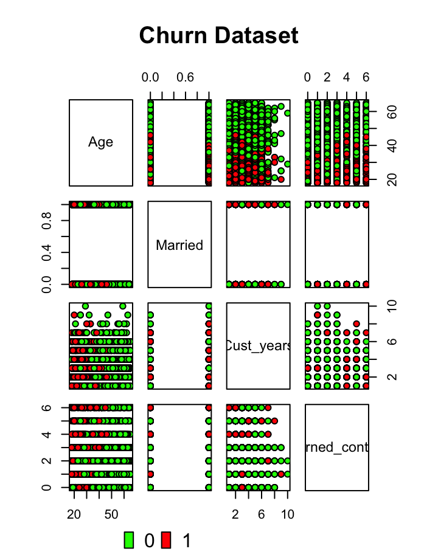

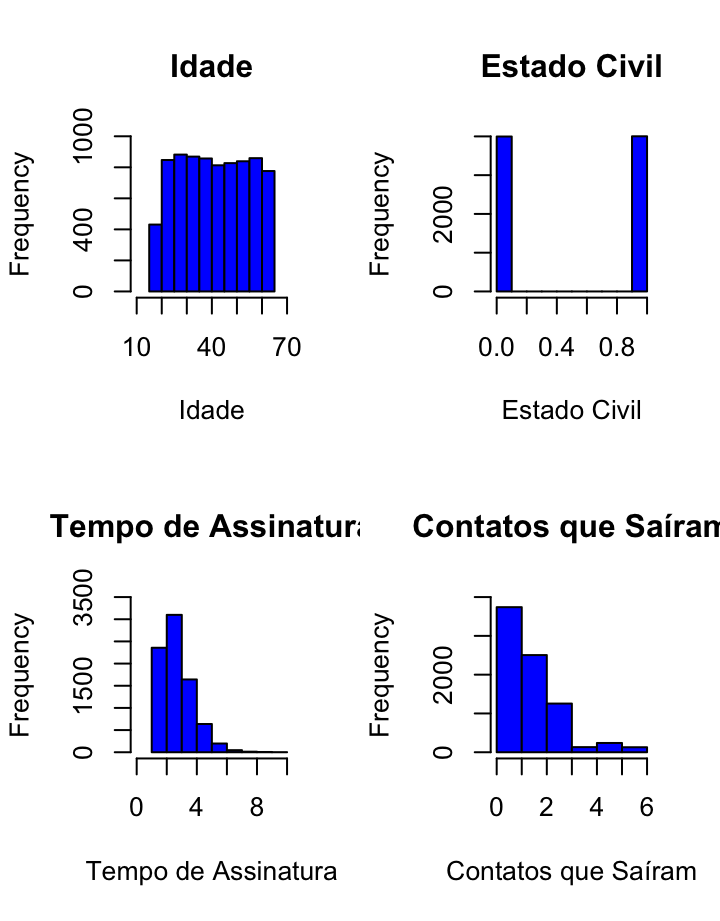

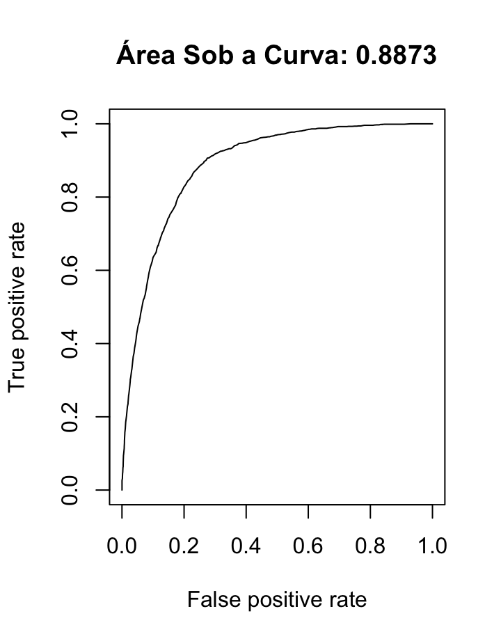

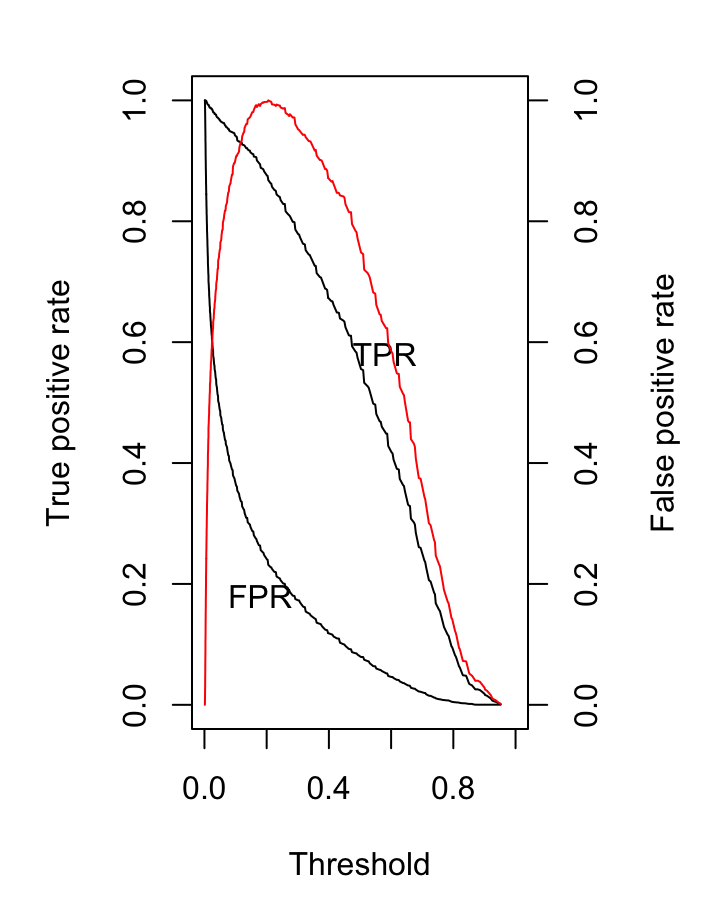

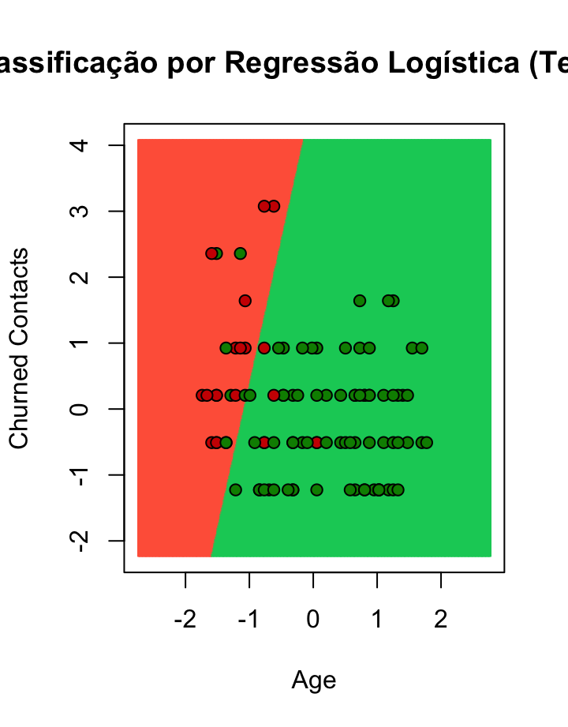

# Intro

**Algoritimo: Regressão Logística**

A regressão logística é uma técnica estatística cujo objetivo é produzir, a partir de um conjunto de observações, um modelo que permita a predição de valores de uma variável categórica, frequentemente binária, a partir de uma série de variáveis explicativas contínuas e/ou binárias. É utilizada em áreas como:

- Em medicina, permite determinar os fatores que caracterizam um grupo de indivíduos doentes em relação a indivíduos sãos.
- No domínio dos seguros, permite encontrar frações da clientela que sejam sensíveis a determinada política securitária em relação a um dado risco particular.
- Em instituições financeiras, pode detectar os grupos de risco para a subscrição de um crédito.
- Em econometria, permite explicar uma variável discreta, como por exemplo as intenções de voto em eleições.

# Área de Dados

### Dados Utilizados:

```
  Age Married Cust_years Churned_contacts Churned
1  61       1          3                1       0
2  50       1          3                2       0
3  47       1          2                0       0
4  50       1          3                3       0
5  29       1          1                3       0
6  43       1          4                3       0
```

A coluna **Churned** indica se o cliente abandonou (1) ou permaneceu com o serviço (0).

### Quantidade de Registros no Dataset:

```
[1] Registros:  8000
```

```
[1] Percentual de abandono:  0.217875
```

### Conjuntos de Treinamento e Teste

```
[1] Registros do Training Set:  7900
```

```
[1] Registros do Test Set:  100
```

### Gráfico de Correlação de Variáveis

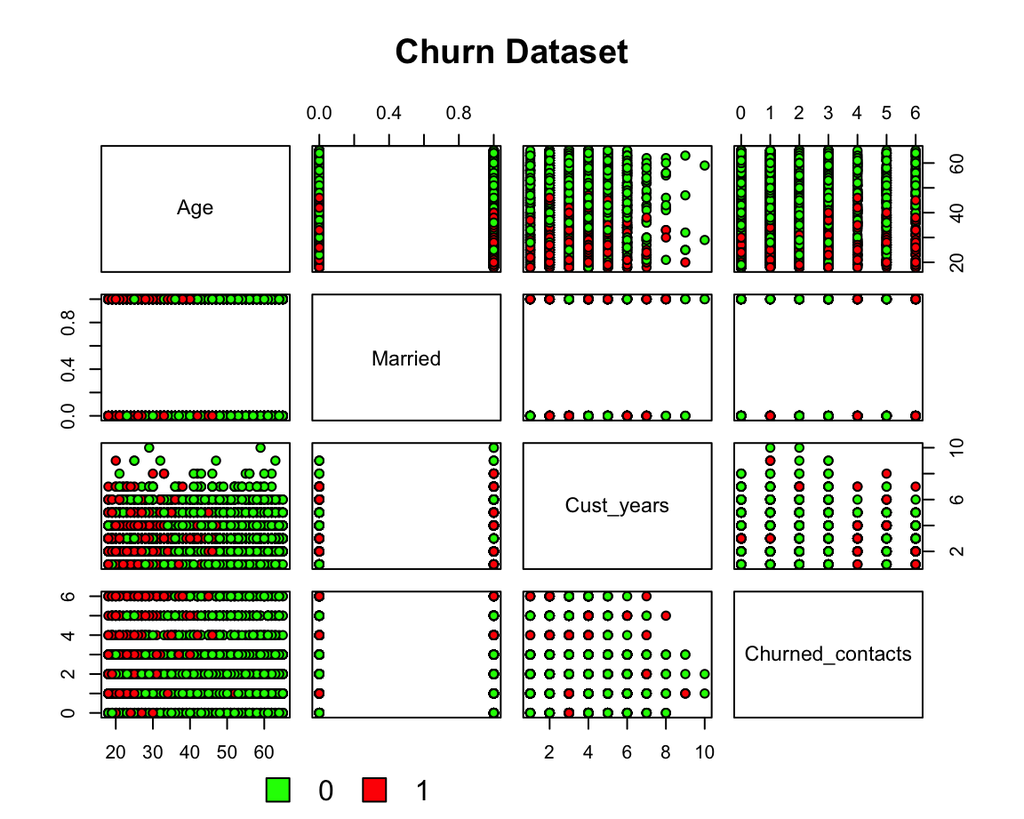

### Histogramas de Frequências

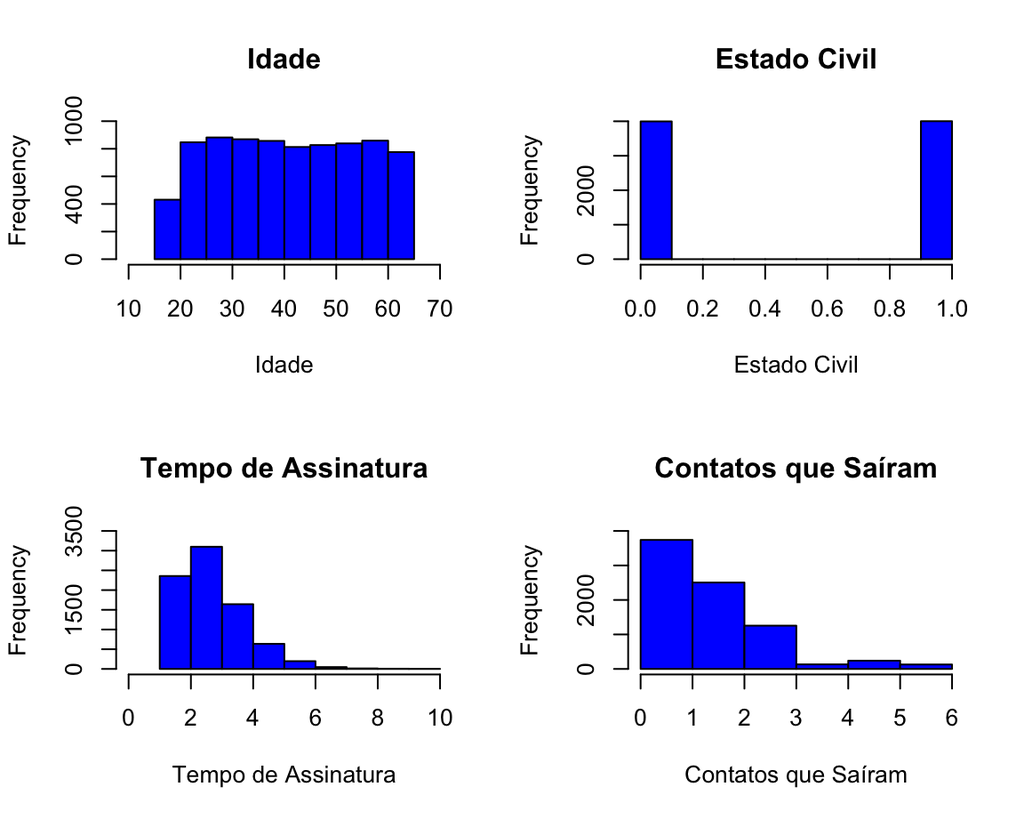

# Modelagem

### Modelagem e Análises:

**Modelagem 1:**

Explicando a **Saída** em função da **Idade**, **Estado Civil**, **Tempo de Assinatura**, **Número de contatos que saíram do serviço**.

```
Call:
glm(formula = Churned ~ Age + Married + Cust_years + Churned_contacts,
    family = binomial(link = "logit"), data = training_set)

Deviance Residuals:
    Min       1Q   Median       3Q      Max
-2.4588  -0.5217  -0.1973  -0.0728   3.3783

Coefficients:
                 Estimate Std. Error z value Pr(>|z|)
(Intercept)      -2.32318    0.05614 -41.384   <2e-16 ***
Age              -2.13318    0.05604 -38.068   <2e-16 ***
Married           0.03303    0.03435   0.962    0.336
Cust_years        0.02254    0.03417   0.660    0.510
Churned_contacts  0.48833    0.03497  13.964   <2e-16 ***
---
Signif. codes:  0 '***' 0.001 '**' 0.01 '*' 0.05 '.' 0.1 ' ' 1

(Dispersion parameter for binomial family taken to be 1)

    Null deviance: 8281.9  on 7899  degrees of freedom
Residual deviance: 5295.3  on 7895  degrees of freedom
AIC: 5305.3

Number of Fisher Scoring iterations: 6
```

Vemos que a variável **Tempo de Assinatura** é pouco significativa, então vamos removê-la do modelo. Também suspeitamos que a variável **Estado Civil** não seja significativa.

**Modelagem 2:**

Explicando a **Saída** em função da **Idade**, **Estado Civil**, **Número de Contatos que saíram do serviço**

```
Call:
glm(formula = Churned ~ Age + Married + Churned_contacts, family = binomial(link = "logit"),
    data = training_set)

Deviance Residuals:
    Min       1Q   Median       3Q      Max
-2.4514  -0.5177  -0.1977  -0.0725   3.3771

Coefficients:
                 Estimate Std. Error z value Pr(>|z|)
(Intercept)      -2.32312    0.05614 -41.382   <2e-16 ***
Age              -2.13304    0.05603 -38.067   <2e-16 ***
Married           0.03305    0.03435   0.962    0.336
Churned_contacts  0.48774    0.03496  13.953   <2e-16 ***
---
Signif. codes:  0 '***' 0.001 '**' 0.01 '*' 0.05 '.' 0.1 ' ' 1

(Dispersion parameter for binomial family taken to be 1)

    Null deviance: 8281.9  on 7899  degrees of freedom
Residual deviance: 5295.8  on 7896  degrees of freedom
AIC: 5303.8

Number of Fisher Scoring iterations: 6
```

Como suspeitávamosa a variável **Estado Civil** também não é significativa para a previsão, portando vamos removê-la do modelo.

**Modelagem 3:**

Explicando a **Saída** em função da **Idade** e do **Número de Contatos que saíram do serviço**

```
Call:
glm(formula = Churned ~ Age + Churned_contacts, family = binomial(link = "logit"),
    data = training_set)

Deviance Residuals:
    Min       1Q   Median       3Q      Max
-2.4637  -0.5225  -0.1960  -0.0738   3.3666

Coefficients:
                 Estimate Std. Error z value Pr(>|z|)
(Intercept)      -2.32230    0.05611  -41.39   <2e-16 ***
Age              -2.13185    0.05600  -38.07   <2e-16 ***
Churned_contacts  0.48773    0.03495   13.96   <2e-16 ***
---
Signif. codes:  0 '***' 0.001 '**' 0.01 '*' 0.05 '.' 0.1 ' ' 1

(Dispersion parameter for binomial family taken to be 1)

    Null deviance: 8281.9  on 7899  degrees of freedom
Residual deviance: 5296.7  on 7897  degrees of freedom
AIC: 5302.7

Number of Fisher Scoring iterations: 6
```

Modelo final: **Churned ~ Age + Churned_contacts**

# Análise

### ROC Curve

Esse indicador representa a performance de um modelo de classificação binário. Quanto mais próxima de 1 for a Área, melhor a performance da previsão.

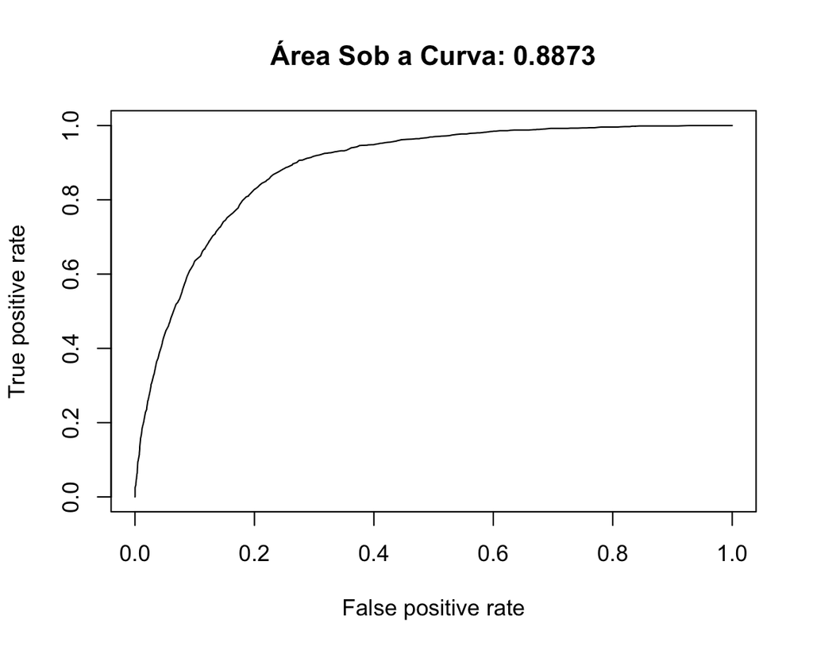

### Gráfico FPR x TPR e Linha de Diferença

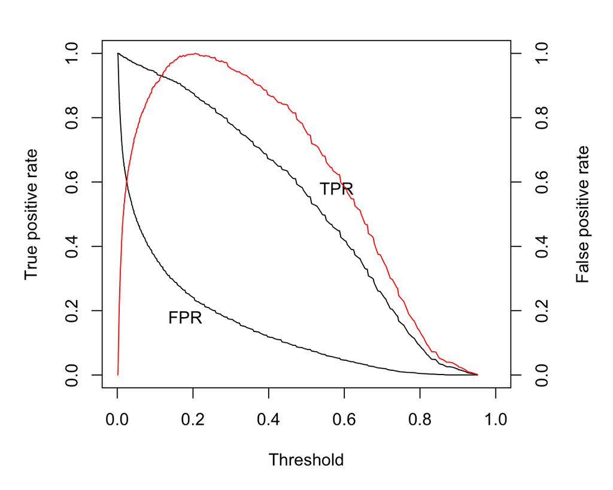

### Calibragem do Parâmetro Alpha (threshold)

Melhor alpha: (Youden Index: Max(TPR-FPR))

```
[1] "0.2052"
```

```
[1] Alpha utilizado na análise: 0.5
```

### Função Logísitica

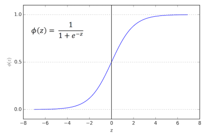

# Métricas de avaliação

**Confusion Matrix**

|  | 0 | 1 |
| --- | --- | --- |
| 0 | 71 | 7 |
| 1 | 7 | 15 |

### **Classificações**

```
[1] True Positives  =  71
```

```
[1] True Negatives  =  15
```

```
[1] False Positives =  7
```

```
[1] False Negatives =  7
```

**Precision**

```
[1] 0.9102564
```

**Recall**

```
[1] 0.9102564
```

**Accuracy**

```
[1] 0.86
```

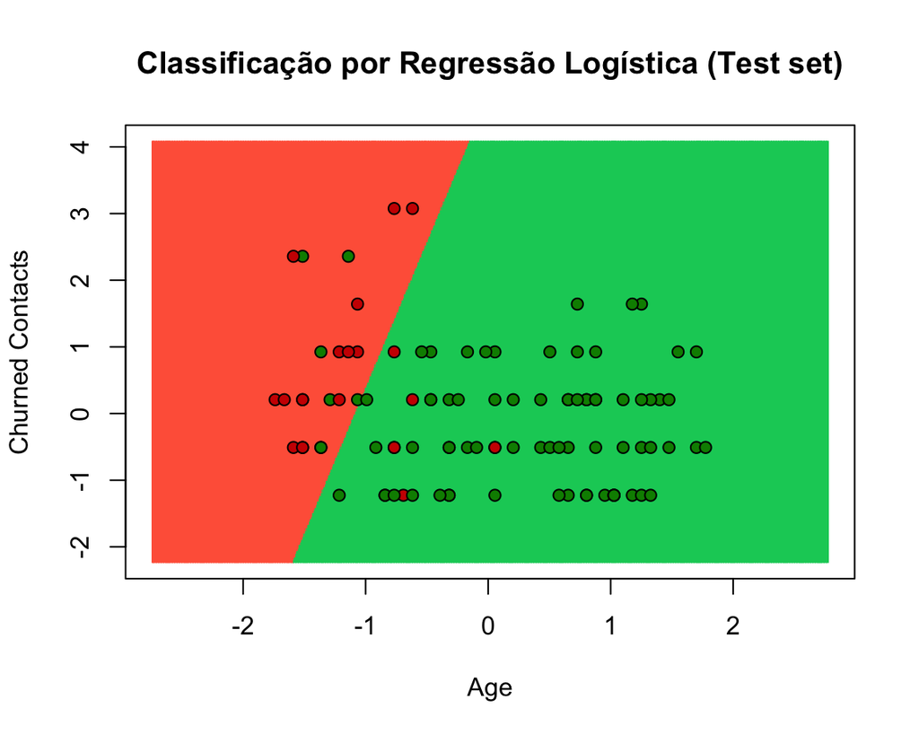

# Previsão

### Previsão de saída para indivíduo

```
[1] Idade: 30
```

```
[1] Churned Contacts: 3
```

```
[1] Previsão: Não Sairá ( Probabilidade de saída: 0.48 )
```

# Outros Algoritmos de Classificação:

- Decision Tree
- Kernel SVM
- KNN
- Naive Bayes
- Randon Forest
- SVM
- Convolutional Neural Networks